# CaseStudy9Markdown

Haleigh Borich

11/3/2021

```r
library(tidyverse)
library(lubridate)
library(downloader)
```

```r
bob1 <- tempfile()
download("https://github.com/WJC-Data-Science/DTS350/raw/master/sales.csv", bob1, mode = "wb")
SaleData <- read_csv(bob1)
SalesData <- with_tz(SaleData, tzone = "US/Mountain")
```

```r
HourlyData <- SalesData %>%
  mutate(hourly = ceiling_date(Time, "hour")) %>%
  mutate(daily = ceiling_date(Time, "day")) %>%
  mutate(Hour = hour(hourly)) %>%
  group_by(Name, Hour) %>%
  summarise(across(Amount, sum))
```

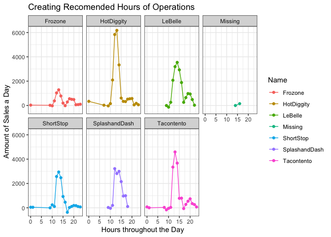

```r
ggplot(HourlyData, aes(x = Hour, y = Amount, color = Name)) +
  geom_point() +
  geom_line() +
  facet_wrap(~ Name, nrow = 2) +
  labs(x = "Hours throughout the Day",
       y = "Amount of Sales a Day",
       title = "Creating Recomended Hours of Operations") +
  theme_bw()
```

My recomendation for store hours is from 9am through 10pm. It seems as though sales start around 8:30am to 9am for the majority of the stores and end around 10pm most days.

```r
DailyData <- SalesData %>%
  mutate(daily = ceiling_date(Time, "day")) %>%
  mutate(Daily = wday(daily)) %>%
  group_by(Name, Daily) %>%
  summarise(across(Amount, sum))
```

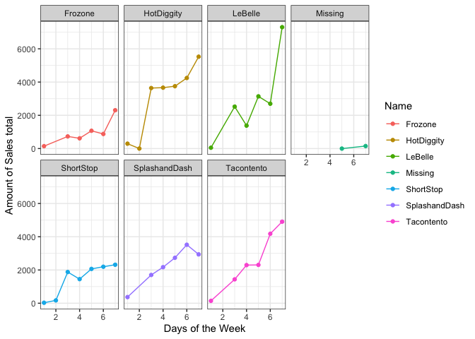

```r
ggplot(DailyData, aes(x = Daily, y = Amount, color = Name)) +
   geom_point() +
   geom_line() +
   facet_wrap(~ Name, nrow = 2) +
  labs(x = "Days of the Week",
       y = "Amount of Sales total",
       tital = "Daily Gross Revenue ") +
   theme_bw()
```

```r
WeeklyData <- SalesData %>%
   mutate(weekly = ceiling_date(Time, "week")) %>%
   mutate(Weekly = week(weekly)) %>%
   group_by(Name, Weekly) %>%
   summarise(across(Amount, sum))
```

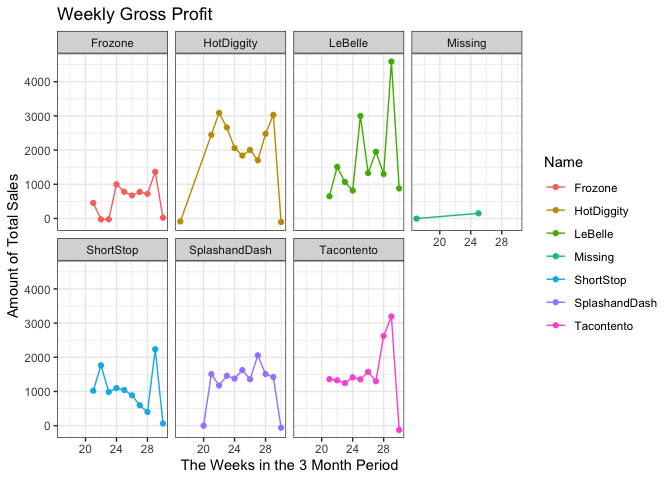

```r
ggplot(WeeklyData, aes(x = Weekly, y = Amount, color = Name)) +
   geom_point() +
   geom_line() +
   facet_wrap(~ Name, nrow = 2) +
  labs(x = "The Weeks in the 3 Month Period",
       y = "Amount of Total Sales",
       title = "Weekly Gross Profit") +
   theme_bw()
```

When we are looking at the Weekly Gross Profit, we can see that it flutuactes over time. There is not one business that has a steady flow of sales.

```r
MonthlyData <- SalesData %>%
   mutate(monthly = ceiling_date(Time, "month")) %>%
   mutate(Monthly = month(monthly)) %>%
   group_by(Name, Monthly) %>%
   summarise(across(Amount, sum))
```

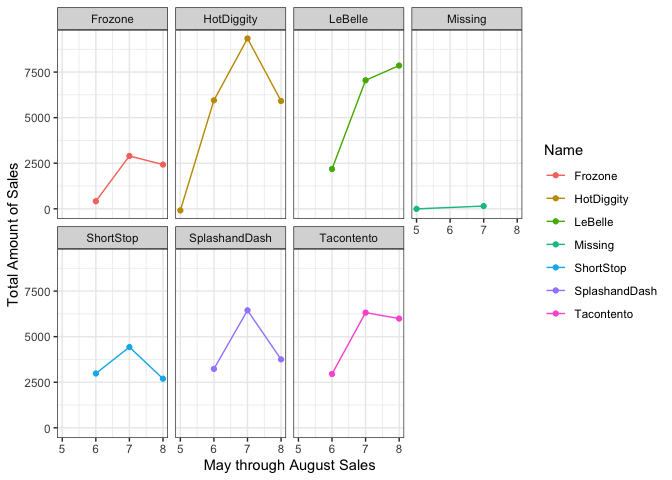

```r
ggplot(MonthlyData, aes(x = Monthly, y = Amount, color = Name)) +
   geom_point() +
   geom_line() +
   facet_wrap(~ Name, nrow = 2) +
  labs(x = "May through August Sales",
       y = "Total Amount of Sales",
       tite = "Gross Revenue for 3 Months ") +
   theme_bw()
```

While we are looking at the three month data, we can see that Hot Diggity has the most sales by far but LaBelle is close behind them.

```r
TotalData <- SalesData %>%
  group_by(Name) %>%
  summarise(across(Amount, sum))
```

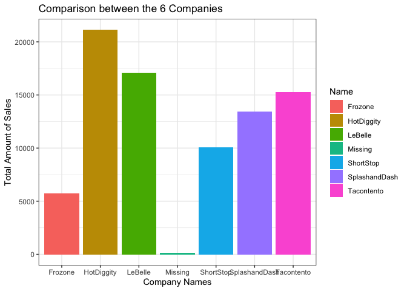

```r
ggplot(TotalData, aes(x = Name, y = Amount, fill = Name)) +
  geom_col() +
  labs(x = "Company Names",
       y = "Total Amount of Sales",
       title = "Comparison between the 6 Companies") +
  theme_bw()
```

It is very clear after looking at this graph that Hot Diggity is the company to invest in, however, Le Belle is very close behind and would be another best option to invest in.